# The application

Muhammad Yaseen

2026-11-05

# 1 Abstract

`mhp_app()` opens an application in the web browser that runs the filters of the package without code: the data, the HP, modified HP and fully modified HP filters, their comparison, the diagnostics of the end-point bias, many series at once and the simulation study. This vignette describes its pages and how it keeps its results reproducible.

# 2 Starting the application

```r
mhp_app(
    launch.browser = TRUE
  )
```

The application needs the suggested packages **shiny**, **bslib** and **DT**. **magick** with WebP support is optional: with it the plots are sent to the browser as WebP images, smaller than the same PNG.

# 3 The pages

| Page | What it does |
| --- | --- |
| Home | what the application does and the order of the pages |
| Data | the `us_macro` example or a CSV file with one series per column; the series, its frequency and first period, and whether to filter its logarithm |
| Filter | the fully modified HP, modified HP or HP filter with its settings; interpretation, plot, table, printed output and R code |
| Compare | the three filters on the same series: moments of the cycles, the end-point loss and the spread of the cycle at the ends and in the middle |
| Diagnostics | the end-point loss, the gain functions or the filter weights for the smoothing parameters of the last fit |
| Batch | every numeric column of the data, each with its own smoothing parameter |
| Simulation | the power comparison of Hanif et al. (2017) for chosen designs |
| References | the articles behind the methods, as `mhp_cite()` prints them |

Every result page has the same tabs:

- **Interpretation** gives the plain-language reading of `mhp_interpret()`, with a button that copies it.
- **Plot** shows the figure, which can be saved as PNG, PDF or WebP.
- **Table** shows the numbers, rounded, in a sortable table with buttons to copy them or save them as CSV or Excel.
- **Output** shows the printed result as text, with a button that copies it.

The filter page has a further tab, **R code**, with the code that reproduces the fit outside the application.

The filter page after the fully modified HP filter of US GDP with the default settings:

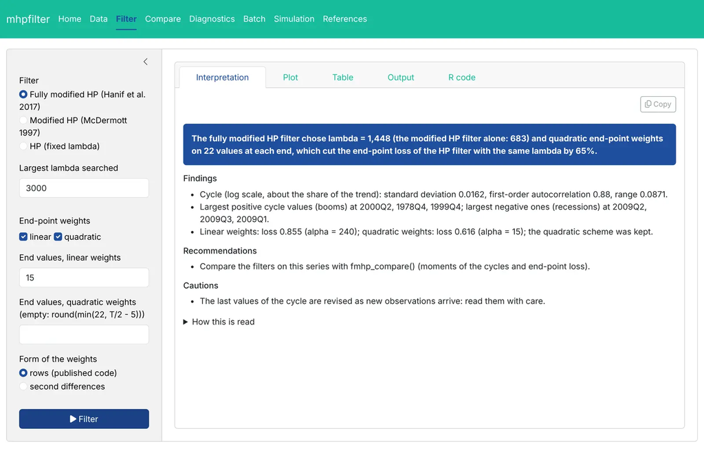

its plot:

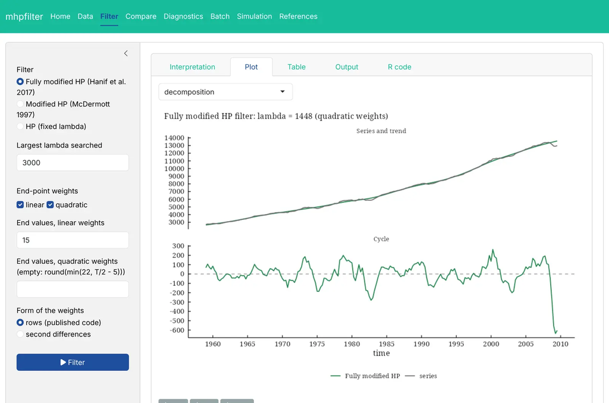

the comparison of the three filters:

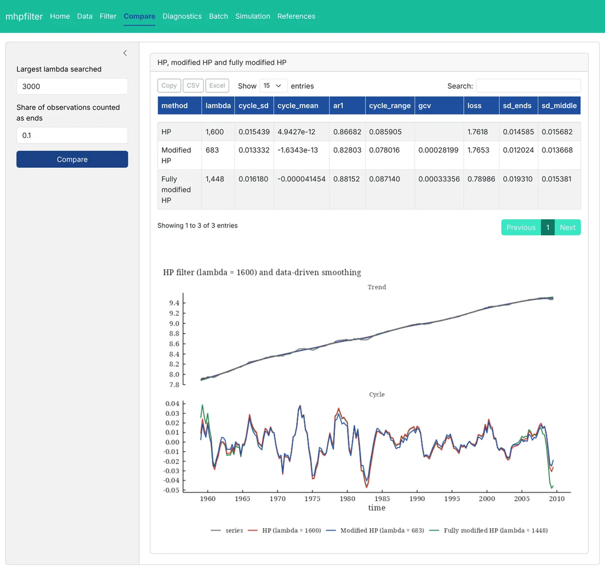

and the end-point loss at the chosen smoothing parameters:

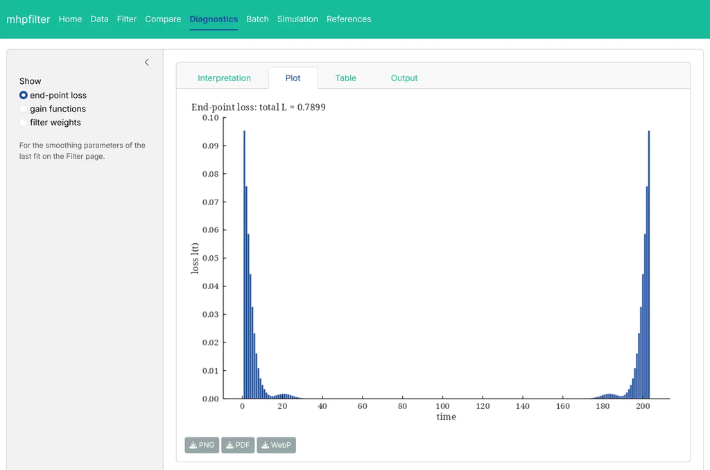

The loss on the diagnostics page (0.79) is larger than the loss in the interpretation (0.62): the procedure chooses the weights by their loss at $\lambda$ of the modified HP filter (683) and then searches $\lambda$ again (1448), and the loss is reported at the first, as in the MATLAB code. The diagnostics page evaluates it at the second.

# 4 Reproducibility

For the settings of the screenshots, the R code tab shows:

```r
settings <-
  list(
      source       = "example"
    , freq         = "4"
    , col          = "gdp"
    , start        = 1959
    , start_period = 1
    , logs         = TRUE
    , method       = "fmhp"
    , max_lambda   = 3000
    , k_linear     = 15
    , k_quadratic  = NA
    , schemes      = c("linear", "quadratic")
    , form         = "rows"
    )
cat(mhpfilter:::.mhp_app_code(input = settings))
```

```
library(mhpfilter)
data(us_macro)
dat <- us_macro
x <- ts(dat$gdp, start = c(1959, 1), frequency = 4)
fit <-
  fmhp_filter(
      x               = x
    , max_lambda      = 3000
    , k_linear        = 15
    , k_quadratic     = NULL
    , alpha_linear    = seq(from = 0, to = 2000, by = 10)
    , alpha_quadratic = seq(from = 0, to = 2000, by = 5)
    , schemes         = c("linear", "quadratic")
    , form            = "rows"
    , lambda          = NULL
    , log_scale       = TRUE
    , as_dt           = FALSE
    )
fit
plot(x = fit)
mhp_interpret(
    x   = fit
  , top = 3
  )
```

The filters are deterministic, so the code returns the same numbers as the application.

# 5 Deploying

`mhp_app_object()` returns the application object without running it, for a server:

```r
# app.R on a Shiny server
mhpfilter::mhp_app_object()
```

# 6 References

Choudhary, M. A., Hanif, M. N. and Iqbal, J. (2014). On smoothing macroeconomic time series using the modified HP filter. *Applied Economics*, 46(19), 2205–2214.

Hanif, M. N., Iqbal, J. and Choudhary, M. A. (2017). Fully modified HP filter. *SBP Working Paper Series*, No. 88, State Bank of Pakistan.